# Postionen Parteien

```r
library(tidyverse)
library(haven)
library(knitr)
```

# GLES Wahlstudie

German Longitudinal Election Study (GLES) 2017 – gles.eu

```r
gles_raw <- haven::read_dta("daten/gles-2017/ZA6801_v2-0-0.dta", encoding = "latin1")
```

## Q-32: Links-Rechts-Selbsteinstufung

*Fragetext:* Und wie ist das mit Ihnen selbst? Wo würden Sie sich auf der Skala von 1 bis 11 einordnen?

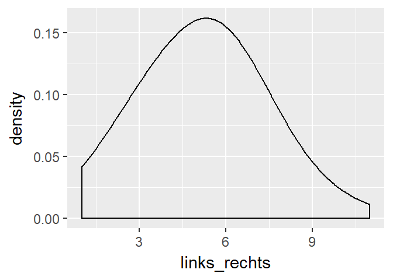

```r
lr_waehler <-
  gles_raw %>%
  mutate(
    variable = "waehler_selbst",
    partei = as_factor(q19ba) %>% as.character(), # zweitstimme
    links_rechts = ifelse(q32 < 0, NA, q32)
    ) %>%
  filter(str_detect(partei, ("^[A-Z]"))) %>%
  select(variable, partei, links_rechts)

ggplot(lr_waehler, aes(x = links_rechts)) +
  geom_density(adjust=5)
```

## Q-31: Links-Rechts-Einstufung Parteien

*Fragetext:* In der Politik reden die Leute häufig von “links” und “rechts”. Wenn Sie diese Skala von 1 bis 11 benutzen, wo würden Sie die folgenden Parteien einordnen, wenn 1 “links” und 11 “rechts” ist?

Items: (A) CDU; (B) CSU; (C) SPD; (D) DIE LINKE; (E) GRÜNE; (F) FDP; (G) AfD

```r
q31_partei <-
  tibble(
    q31 = letters[1:7],
    partei = c("CDU/CSU", "CDU/CSU", "SPD", "DIE LINKE", "GRUENE", "FDP", "AfD")
  )

lr_q31 <-
  gles_raw %>%
  mutate(zweitstimme = as_factor(q19ba) %>% as.character()) %>%
  select(zweitstimme, starts_with("q31")) %>%
  gather(q31, links_rechts, -zweitstimme)

lr_partei <-
  lr_q31 %>%
  mutate(
    variable = "befragte_partei",
    q31 = str_replace(q31, "q31", "")
    ) %>%
  left_join(q31_partei) %>%
  filter(links_rechts >= 0) %>%
  select(-q31)

lr_wa_pa <-
  lr_partei %>%
  filter(zweitstimme == partei) %>%
  mutate(variable = "waehler_partei")
```

#### Positionen Parteien

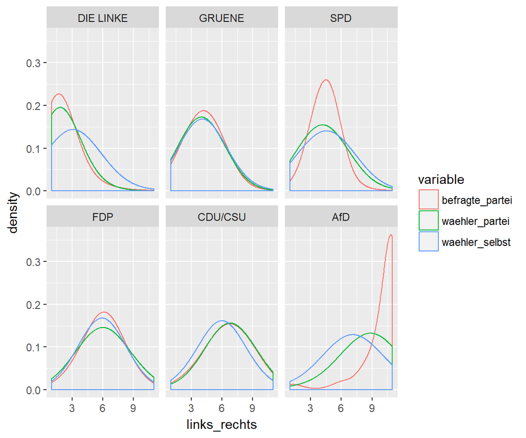

```r
partei_factor <- c("DIE LINKE", "GRUENE", "SPD", "FDP", "CDU/CSU", "AfD")
lr <-
  bind_rows(lr_waehler, lr_partei, lr_wa_pa) %>%
  mutate(partei = fct_relevel(partei, partei_factor))

ggplot(lr, aes(x = links_rechts, colour = variable)) +
  geom_density(adjust=5) +
  facet_wrap(~partei)
```

# CHES expert survey

https://www.chesdata.eu/1999-2014-chapel-hill-expert-survey-ches-trend-file

## Two-dimensional space

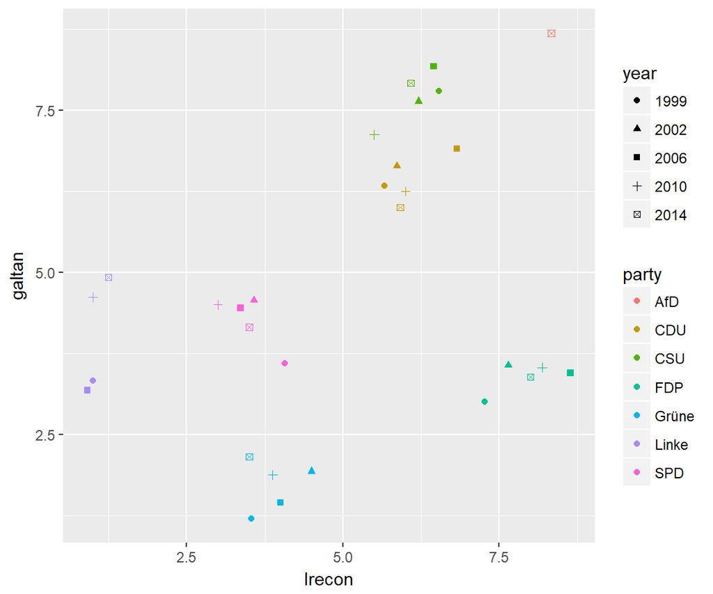

```r
ches_raw <- read_dta("daten/ches-2014/1999-2014_CHES_dataset_means-3.dta")

ches_deu <-
  ches_raw %>%
  zap_labels() %>%
  filter(country == 3, vote > 4) %>%
  mutate(
    year = as.factor(year),
    party = case_when(
      party %in% c("LINKE", "Linkspartei/PDS", "PDS") ~ "Linke",
      party == "Grunen" ~ "Grüne",
      TRUE ~ party
      )
    )

ggplot(ches_deu, aes(x=lrecon, y=galtan, colour = party, shape = year)) + geom_point()
```

**LRECON** – position of the party in YEAR in terms of its ideological **stance on economic issues**. Parties can be classified in terms of their stance on economic issues. Parties on the economic left want government to play an active role in the economy. Parties on the economic right emphasize a reduced economic role for government: privatization, lower taxes, less regulation, less government spending, and a leaner welfare state.

## Most important issue in 2014

Most Important Issue – Only asked in 2014

Entries for the next three questions are a summary of the expert responses to the Most Important Issue question. Each expert ranked one issue as the most important, one issue as the second most important, and one issue as the third most important issue. In this dataset, we aggregate these responses using a simple ordinal voting technique. For each party, an issue received 10 points if it is ranked as the #1 issue by an expert, 5 points if it is ranked #2 by an expert, and 1 point if it is ranked #3 by an expert. After adding together the issue scores for all the experts for each individual party, we ranked each issue by the total number of points, yielding the MIP_ONE, MIP_TWO, and MIP_THREE variables. As the table shows, some parties have ties for the most important issue questions, which reflects the experts’ uncertainty or disagreement on particular parties.11

- MIP_ONE = most important issue for the party over the course of YEAR.
- MIP_TWO = second most important issue for the party over the course of YEAR.
- MIP_THREE = third most important issue for the party over the course of YEAR.

```r
mip_issues <- read_csv("daten/ches-2014/most-important-issue.csv")
mip <-
  ches_deu %>%
  select(party, year, starts_with("mip_")) %>%
  gather(key, id, -party, -year) %>%
  filter(! is.na(id)) %>%
  left_join(mip_issues) %>%
  arrange(party, key) %>%
  select(party, key, issue)

mip %>%
  spread(key, issue) %>%
  select(party, mip_one, mip_two, mip_three) %>%
  kable()
```

| party | mip_one | mip_two | mip_three |
| --- | --- | --- | --- |
| AfD | EU integration | Immigration | Public services vs taxes |
| CDU | EU integration | International security | Public services vs taxes |
| CSU | Public services vs taxes | EU integration | Decentralization |
| FDP | Public services vs taxes | Deregulation | EU integration |
| Grüne | Environment | NA | EU integration |
| Linke | Redistribution | State intervention | Public services vs taxes |
| SPD | EU integration | Redistribution | Public services vs taxes |

# Manifesto content analysis

https://manifesto-project.wzb.eu/

## rile – right-left position of party

Right-left position of party as given in Michael Laver/Ian Budge (eds.): Party Policy and Government Coalitions, Houndmills, Basingstoke, Hampshire: The MacMillan Press 1992:

```
rile =
  (per104 + per201 + per203 + per305 + per401 + per402 + per407 +
   per414 + per505 + per601 + per603 + per605 + per606)
  - (per103 + per105 + per106 + per107 + per403 + per404 + per406 +
     per412 + per413 + per504 + per506 + per701 + per202)
```

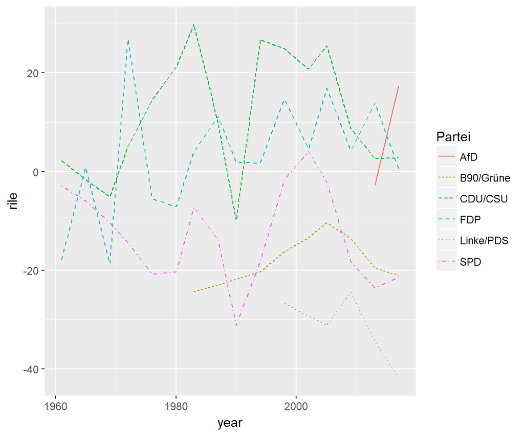

```r
manifesto_raw <- read_csv("daten/manifesto-2017//MPDataset_MPDS2017b.csv")

ma_deu <-
  manifesto_raw %>%
  filter(countryname == "Germany", pervote > 4.5, date > 196000) %>%
  mutate(
    year = date %/% 100,
    rile = round(rile, 1),
    Partei = case_when(
      party %in% c(41111, 41113) ~ "B90/Grüne",
      party %in% c(41221, 41222, 41223) ~ "Linke/PDS",
      TRUE ~ partyabbrev
    )
  )

ggplot(ma_deu, aes(x = year, y = rile, colour = Partei, linetype = Partei)) + geom_line()
```

## Germany 2017 manifestos

```r
ma_var <- read_csv("daten/manifesto-2017/variables.csv")

path <- "daten/manifesto-2017/Germany-2017/"
ma_files <- list.files(path, pattern = "csv$")
ma_2017_raw <- map_df(ma_files, ~ read_csv(paste0(path, .x)) %>% mutate(file = .x))

ma_2017 <-
  ma_2017_raw %>%
  mutate(party = str_extract(file, "\\d+") %>% as.integer()) %>%
  left_join(ma_deu %>% distinct(party, partyabbrev)) %>%
  filter(! cmp_code %in% c("H", "0")) %>%
  select(partyabbrev, cmp_code, content) %>%
  group_by(partyabbrev)
```

#### Most frequent categories

```r
cmp_code_info <-
  ma_var %>%
  select(cmp_code = variable, label) %>%
  mutate(cmp_code = str_remove(cmp_code, "^per"),
         cmp_code = str_replace_all(cmp_code, "_", "."))

ma_2017 %>%
  count(cmp_code) %>%
  arrange(-n) %>%
  left_join(cmp_code_info) %>%
  slice(1:3) %>%
  kable
```

| partyabbrev | cmp_code | n | label |
| --- | --- | --- | --- |
| 90/Greens | 503 | 521 | equality + |
| 90/Greens | 501 | 345 | environmentalism + |
| 90/Greens | 416.2 | 302 | sub2: sustainability + |
| AfD | 601.2 | 80 | sub2: national way of life: immigration - |
| AfD | 603 | 78 | traditional morality + |
| AfD | 110 | 59 | europe - |
| CDU/CSU | 411 | 131 | technology & infrastructure |
| CDU/CSU | 504 | 83 | welfare + |
| CDU/CSU | 403 | 70 | market regulation |
| FDP | 411 | 180 | technology & infrastructure |
| FDP | 201.1 | 165 | sub2: freedom |
| FDP | 403 | 158 | market regulation |
| LINKE | 503 | 799 | equality + |
| LINKE | 504 | 442 | welfare + |
| LINKE | 701 | 360 | labour groups + |
| SPD | 503 | 246 | equality + |
| SPD | 411 | 192 | technology & infrastructure |
| SPD | 504 | 192 | welfare + |

#### Examples classified quasi-sentences

```r
ma_2017 %>%
  left_join(cmp_code_info) %>%
  slice(1:4) %>%
  kable
```

| partyabbrev | cmp_code | content | label |
| --- | --- | --- | --- |
| 90/Greens | 202.1 | Bevor wir Ihnen sagen, was wir vorhaben, haben wir eine Bitte an Sie: Diskutieren Sie mit, mischen Sie sich ein, gehen Sie wählen. | sub2: democracy: general + |
| 90/Greens | 201.1 | Treten Sie mit uns für die Werte ein, die unser Land und Europa stark und lebenswert gemacht haben, die uns weit über Partei- und Ländergrenzen hinweg verbinden: die Würde des Menschen, | sub2: freedom |
| 90/Greens | 503 | Gerechtigkeit und Gleichberechtigung, | equality + |
| 90/Greens | 201.1 | Freiheit und Demokratie. | sub2: freedom |
| AfD | 503 | Wir wollen Deutschland reformieren und an die Prinzipien und Wurzeln anknüpfen, die zu seinem jahrzehntelangen sozialen, | equality + |
| AfD | 410 | wirtschaftlichen | economic growth + |
| AfD | 601.1 | und gesellschaftlichen Erfolg geführt haben. | sub2: national way of life: general + |
| AfD | 203 | Die Rechtsstaatlichkeit muss wiederhergestellt werden, | constitution + |
| CDU/CSU | 601.1 | Deutschland ist ein liebens- und lebenswertes Land, in dem man gut wohnen, arbeiten und leben kann: | sub2: national way of life: general + |
| CDU/CSU | 601.1 | Der großen Mehrheit unserer Bürgerinnen und Bürger ging es noch nie so gut wie heute. | sub2: national way of life: general + |
| CDU/CSU | 601.1 | Unsere Wirtschaft wächst. | sub2: national way of life: general + |
| CDU/CSU | 601.1 | Es gibt in Deutschland mehr Beschäftigung als je zuvor. | sub2: national way of life: general + |
| FDP | 411 | Die Digitalisierung formt unsere Wirtschaft um. | technology & infrastructure |
| FDP | 411 | Selbst gestandene Unternehmen aus Industrie und Finanzwesen drohen, den Anschluss zu verlieren. | technology & infrastructure |
| FDP | 411 | Immer schnellere Medien konkurrieren um unsere Aufmerksamkeit. | technology & infrastructure |
| FDP | 202.1 | Wir sehen, wie extreme Gruppen von Links und Rechts die politische Landschaft verändern. | sub2: democracy: general + |
| LINKE | 606.1 | Es liegt an uns allen. | sub2: civic mindedness: general + |
| LINKE | 606.1 | Wir können das Land verändern. | sub2: civic mindedness: general + |
| LINKE | 503 | Wir können die Zukunft für die Menschen gerechter und besser machen. | equality + |
| LINKE | 503 | Ein gutes Leben für alle wäre längst möglich. | equality + |
| SPD | 305.1 | Die SPD tritt an, um mit Martin Schulz als Bundeskanzler die Weichen für die Zukunft Deutschlands und Europas zu stellen. | sub2: political authority: party competence |
| SPD | 503 | Werte, die als selbstverständlich galten, stehen auf dem Spiel. | equality + |
| SPD | 503 | Für diese Werte kämpfen wir, wie wir es in unserer langen Geschichte immer getan haben. | equality + |
| SPD | 503 | Für eine Gesellschaft, die jedem Menschen respektvoll und mit Würde begegnet. | equality + |